# Locked Down or Locked In? Institutionalized Public Preferences and Pandemic Policy Feedback in 32 Countries

This is a follow up study of

Breznau, Nate. 2020. “The Welfare State and Risk Perceptions: The Novel Coronavirus Pandemic and Public Concern in 70 Countries.” *European Societies*.

The following files are necessary to run this code **ACLED COVID-19 Disorder Tracker** *coronavirus_Aug01.xlsx*: [link](https://osf.io/usq5b/)

Fetzer, T., Witte, M., Hensel, L., Jachimowicz, J.M., Haushofer, J., Ivchenko, A., Caria, C., Reutskaja, E., Roth, C., Fiorin, F., Gomez, M., Kraft-Todd, G., Goetz, F., & Yoeli, E.. Global Behaviors and Perceptions in the COVID-19 Pandemic. https://doi.org/10.31234/osf.io/3kfmh

**Blavatnik School of Gov. Covid Stringency Index** *covid-stringency-index.csv*: [link](https://ourworldindata.org/grapher/covid-stringency-index%20WID_Data_14082020-111941.xlsx) Dowloaded via [‘Our World in Data’](https://wid.world/data/)

**ISSP RoG 2016** Available from GESIS *ZA6900_v2-0-0.dta*

**Solt Gini Data** *swiid9_0.rda* Solt, Frederick. 2020. “Measuring Income Inequality Across Countries and Over Time: The Standardized World Income Inequality Database.” Social Science Quarterly doi: 10.1111/ssqu.12795

### Setup

```r
wdir <- function(x){
  paste(getwd(),x, sep = "/")
}

# need pacman package installed to run this
# install.packages("pacman")
pacman::p_load("dplyr","countrycode","car","ggplot2","jtools","sjPlot","sjmisc","sjlabelled","tidyverse","psych","lavaan","kableExtra","ggrepel","stringi","margins","readxl","semPlot","htmlTable", "countrycode","haven","semTable","ragg")
```

### Load Data

```r
# COVID-19 Survey

betrack <- read_dta(wdir("data/GlobalBehaviorsPerceptions_Data_May21_2020.dta"))

# government response
gov_resp <- read.csv(file = wdir("data/OxCGRT_latest.csv"), header = T)


# ISSP RoG
issp16 <- read_dta(wdir("data/ZA6900_v2-0-0.dta"))

# Solt Gini
swiid <- load(wdir("data/swiid9_0.rda"))

# Death per million

covid <- read.csv(file = wdir("data/owid-covid-data.csv"), header = T)

## GDP per capita (2019)
gdp <- read.csv(file = wdir("data/GDP per capita WB.csv"), header = T,skip = 4)

## Social Spending

socp <- read_xlsx(wdir("data/54614.xlsx"), skip = 5, sheet = 1)
```

### Government Intervention Measurement

Here we create and test a scale of institutionalized preferences for government intervention into the personal lives of individuals.

Take questions about government’s intervention in unlikely events (public security, national security, terrorist act). These questions only exist in issp16

#### Results for Gov. Intervention Measurement

Full multi-group invariance tables are available in the results folder. Below this chunk are fit indices. Naturally a model with only 3 variables has a just-identified baseline and configural invariance model (with the groups freely estimated). Therefore, we rely mostly on the theoretical validity of these measures reflecting an institutionalized type of preference of whether the govenrment has the right in certain circumstances to intervene in private affairs that causes similarites in response patterns across these three items.

```
## lavaan 0.6-7 ended normally after 26 iterations
##
##   Estimator                                         ML
##   Optimization method                           NLMINB
##   Number of free parameters                          6
##
##   Number of observations                         36068
##
## Model Test User Model:
##
##   Test statistic                                 0.000
##   Degrees of freedom                                 0
##
## Model Test Baseline Model:
##
##   Test statistic                             16327.277
##   Degrees of freedom                                 3
##   P-value                                        0.000
##
## User Model versus Baseline Model:
##
##   Comparative Fit Index (CFI)                    1.000
##   Tucker-Lewis Index (TLI)                       1.000
##
## Loglikelihood and Information Criteria:
##
##   Loglikelihood user model (H0)            -187026.412
##   Loglikelihood unrestricted model (H1)    -187026.412
##
##   Akaike (AIC)                              374064.824
##   Bayesian (BIC)                            374115.783
##   Sample-size adjusted Bayesian (BIC)       374096.715
##
## Root Mean Square Error of Approximation:
##
##   RMSEA                                          0.000
##   90 Percent confidence interval - lower         0.000
##   90 Percent confidence interval - upper         0.000
##   P-value RMSEA <= 0.05                             NA
##
```

[output cut: 8 more lines]

```
##   Information saturated (h1) model          Structured
##
## Latent Variables:
##                    Estimate  Std.Err  z-value  P(>|z|)
##   preference =~
##     gov_surveil       1.000
##     gov_surveil2      1.225    0.018   67.866    0.000
##     gov_secure        1.001    0.014   71.724    0.000
##
## Variances:
##                    Estimate  Std.Err  z-value  P(>|z|)
##    .gov_surveil       1.329    0.014   92.774    0.000
##    .gov_surveil2      1.004    0.017   58.193    0.000
##    .gov_secure        1.495    0.015   98.221    0.000
##     preference        0.757    0.016   47.839    0.000
```

```
## lavaan 0.6-7 ended normally after 425 iterations
##
##   Estimator                                         ML
##   Optimization method                           NLMINB
##   Number of free parameters                        297
##
##   Number of observations per group:
##     2                                             1307
##     101                                            955
##     115                                            682
##     155                                           1035
##     200                                           1182
##     211                                           1422
##     220                                           1091
##     225                                            892
##     230                                           1291
##     255                                           1265
##     316                                           1113
##     317                                            946
##     344                                            975
##     349                                            860
##     365                                           1184
##     367                                            820
##     368                                            800
##     375                                            801
##     380                                            799
##     385                                            927
##     390                                            903
##     395                                            949
##     560                                           2794
##     640                                           1227
##     666                                           1034
##     713                                           1682
##     732                                           1018
##     740                                           1039
##     750                                           1101
##     800                                            971
##     840                                           1163
##     900                                            975
##     920                                            865
```

[output cut: 853 more lines]

```
##     gov_secure        1.053    0.077   13.625    0.000
##
## Intercepts:
##                    Estimate  Std.Err  z-value  P(>|z|)
##    .gov_surveil       3.879    0.044   88.713    0.000
##    .gov_surveil2      2.689    0.049   55.360    0.000
##    .gov_secure        3.236    0.049   66.570    0.000
##     preference        0.000
##
## Variances:
##                    Estimate  Std.Err  z-value  P(>|z|)
##    .gov_surveil       0.882    0.066   13.359    0.000
##    .gov_surveil2      0.932    0.085   10.912    0.000
##    .gov_secure        1.189    0.080   14.849    0.000
##     preference        0.772    0.084    9.171    0.000
```

```
## lavaan 0.6-7 ended normally after 178 iterations
##
##   Estimator                                         ML
##   Optimization method                           NLMINB
##   Number of free parameters                        297
##   Number of equality constraints                    64
##
##   Number of observations per group:
##     2                                             1307
##     101                                            955
##     115                                            682
##     155                                           1035
##     200                                           1182
##     211                                           1422
##     220                                           1091
##     225                                            892
##     230                                           1291
##     255                                           1265
##     316                                           1113
##     317                                            946
##     344                                            975
##     349                                            860
##     365                                           1184
##     367                                            820
##     368                                            800
##     375                                            801
##     380                                            799
##     385                                            927
##     390                                            903
##     395                                            949
##     560                                           2794
##     640                                           1227
##     666                                           1034
##     713                                           1682
##     732                                           1018
##     740                                           1039
##     750                                           1101
##     800                                            971
##     840                                           1163
##     900                                            975
```

[output cut: 855 more lines]

```
##     gov_scr (.p3.)    0.933    0.013   69.291    0.000
##
## Intercepts:
##                    Estimate  Std.Err  z-value  P(>|z|)
##    .gov_surveil       3.879    0.044   87.829    0.000
##    .gov_surveil2      2.689    0.049   55.122    0.000
##    .gov_secure        3.236    0.048   67.788    0.000
##     preference        0.000
##
## Variances:
##                    Estimate  Std.Err  z-value  P(>|z|)
##    .gov_surveil       0.856    0.057   15.032    0.000
##    .gov_surveil2      0.913    0.068   13.342    0.000
##    .gov_secure        1.247    0.071   17.458    0.000
##     preference        0.831    0.057   14.566    0.000
```

```
## lavaan 0.6-7 ended normally after 183 iterations
##
##   Estimator                                         ML
##   Optimization method                           NLMINB
##   Number of free parameters                        264
##   Number of equality constraints                    31
##
##   Number of observations per group:
##     2                                             1307
##     101                                            955
##     115                                            682
##     155                                           1035
##     200                                           1182
##     211                                           1422
##     220                                           1091
##     225                                            892
##     230                                           1291
##     255                                           1265
##     316                                           1113
##     317                                            946
##     344                                            975
##     349                                            860
##     365                                           1184
##     367                                            820
##     368                                            800
##     375                                            801
##     380                                            799
##     385                                            927
##     390                                            903
##     395                                            949
##     560                                           2794
##     640                                           1227
##     666                                           1034
##     713                                           1682
##     732                                           1018
##     740                                           1039
##     750                                           1101
##     800                                            971
##     840                                           1163
##     900                                            975
```

[output cut: 1020 more lines]

```
##    .gov_secure (a)    0.017    0.010    1.689    0.091
##
## Intercepts:
##                    Estimate  Std.Err  z-value  P(>|z|)
##    .gov_surveil       3.879    0.044   88.064    0.000
##    .gov_surveil2      2.689    0.049   55.073    0.000
##    .gov_secure        3.236    0.048   67.699    0.000
##     interven_scrty    0.000
##
## Variances:
##                    Estimate  Std.Err  z-value  P(>|z|)
##    .gov_surveil       0.851    0.056   15.098    0.000
##    .gov_surveil2      0.923    0.068   13.637    0.000
##    .gov_secure        1.257    0.071   17.595    0.000
##     interven_scrty    0.827    0.055   14.919    0.000
```

|  | Fit Index | Baseline | Configural | Metric | Metric X |
| --- | --- | --- | --- | --- | --- |
| 1 | Chi-square | 0 | 0 | 578.27 | 516.282 |
| 2 | df | 0 | 0 | 64 | 64 |
| 3 | RMSEA | 0 | 0 | 0.086 | 0.08 |
| 4 | CFI | 1 | 1 | 0.968 | 0.972 |
| 5 | TLI | 1 | 1 | 0.95 | 0.956 |
| 6 | AIC | 374065 | 360400 | 360850 | 360788 |
| 7 | LL | -187026 | -179903 | -180192 | -180161 |

### Behaviors Measurment

Here we rescale behaviors from their 0-100 metric, into a standardized scale to make them easy to interpret. There is no missing data because this was already removed by the PIs of the survey prior to making it publicly available.

#### Measurement Invariance - Behaviors

#### Results for Public Behaviors Measurement

```
## lavaan 0.6-7 ended normally after 19 iterations
##
##   Estimator                                         ML
##   Optimization method                           NLMINB
##   Number of free parameters                          6
##
##   Number of observations                         65124
##
## Model Test User Model:
##
##   Test statistic                                 0.000
##   Degrees of freedom                                 0
##
## Model Test Baseline Model:
##
##   Test statistic                             36155.610
##   Degrees of freedom                                 3
##   P-value                                        0.000
##
## User Model versus Baseline Model:
##
##   Comparative Fit Index (CFI)                    1.000
##   Tucker-Lewis Index (TLI)                       1.000
##
## Loglikelihood and Information Criteria:
##
##   Loglikelihood user model (H0)            -249968.667
##   Loglikelihood unrestricted model (H1)    -249968.667
##
##   Akaike (AIC)                              499949.333
##   Bayesian (BIC)                            500003.838
##   Sample-size adjusted Bayesian (BIC)       499984.770
##
## Root Mean Square Error of Approximation:
##
##   RMSEA                                          0.000
##   90 Percent confidence interval - lower         0.000
##   90 Percent confidence interval - upper         0.000
##   P-value RMSEA <= 0.05                             NA
##
```

[output cut: 8 more lines]

```
##   Information saturated (h1) model          Structured
##
## Latent Variables:
##                    Estimate  Std.Err  z-value  P(>|z|)
##   behave =~
##     stay              1.000
##     gather            0.789    0.007  107.008    0.000
##     distance          0.971    0.009  106.843    0.000
##
## Variances:
##                    Estimate  Std.Err  z-value  P(>|z|)
##    .stay              0.492    0.005   99.874    0.000
##    .gather            0.565    0.004  139.749    0.000
##    .distance          0.439    0.005   95.991    0.000
##     behave            0.483    0.006   77.722    0.000
```

```
## lavaan 0.6-7 ended normally after 1182 iterations
##
##   Estimator                                         ML
##   Optimization method                           NLMINB
##   Number of free parameters                        306
##
##   Number of observations per group:
##     900                                            947
##     211                                            574
##     225                                           4198
##     155                                            548
##     316                                            263
##     255                                          10192
##     390                                            508
##     230                                           2327
##     375                                            794
##     220                                           2781
##     200                                          11270
##     372                                             45
##     344                                             62
##     310                                            239
##     666                                            407
##     750                                            992
##     395                                             23
##     740                                            578
##     732                                            295
##     368                                             94
##     367                                            676
##     385                                            302
##     920                                            360
##     840                                            749
##     365                                           3399
##     380                                           5858
##     349                                             54
##     317                                            610
##     800                                            309
##     640                                           2865
##     713                                            140
##     2                                            11459
##     101                                            658
```

[output cut: 879 more lines]

```
##     distance          0.907    0.095    9.559    0.000
##
## Intercepts:
##                    Estimate  Std.Err  z-value  P(>|z|)
##    .stay             -0.057    0.043   -1.314    0.189
##    .gather           -0.040    0.043   -0.931    0.352
##    .distance          0.013    0.040    0.332    0.740
##     behave            0.000
##
## Variances:
##                    Estimate  Std.Err  z-value  P(>|z|)
##    .stay              0.481    0.059    8.101    0.000
##    .gather            0.704    0.052   13.597    0.000
##    .distance          0.420    0.050    8.467    0.000
##     behave            0.542    0.075    7.205    0.000
```

```
## lavaan 0.6-7 ended normally after 369 iterations
##
##   Estimator                                         ML
##   Optimization method                           NLMINB
##   Number of free parameters                        306
##   Number of equality constraints                    66
##
##   Number of observations per group:
##     900                                            947
##     211                                            574
##     225                                           4198
##     155                                            548
##     316                                            263
##     255                                          10192
##     390                                            508
##     230                                           2327
##     375                                            794
##     220                                           2781
##     200                                          11270
##     372                                             45
##     344                                             62
##     310                                            239
##     666                                            407
##     750                                            992
##     395                                             23
##     740                                            578
##     732                                            295
##     368                                             94
##     367                                            676
##     385                                            302
##     920                                            360
##     840                                            749
##     365                                           3399
##     380                                           5858
##     349                                             54
##     317                                            610
##     800                                            309
##     640                                           2865
##     713                                            140
##     2                                            11459
```

[output cut: 881 more lines]

```
##     distanc (.p3.)    0.960    0.011   89.433    0.000
##
## Intercepts:
##                    Estimate  Std.Err  z-value  P(>|z|)
##    .stay             -0.057    0.043   -1.324    0.185
##    .gather           -0.040    0.043   -0.924    0.355
##    .distance          0.013    0.040    0.331    0.741
##     behave            0.000
##
## Variances:
##                    Estimate  Std.Err  z-value  P(>|z|)
##    .stay              0.507    0.043   11.688    0.000
##    .gather            0.695    0.049   14.268    0.000
##    .distance          0.408    0.037   10.967    0.000
##     behave            0.501    0.043   11.564    0.000
```

```
## lavaan 0.6-7 ended normally after 393 iterations
##
##   Estimator                                         ML
##   Optimization method                           NLMINB
##   Number of free parameters                        272
##   Number of equality constraints                    32
##
##   Number of observations per group:
##     900                                            947
##     211                                            574
##     225                                           4198
##     155                                            548
##     316                                            263
##     255                                          10192
##     390                                            508
##     230                                           2327
##     375                                            794
##     220                                           2781
##     200                                          11270
##     372                                             45
##     344                                             62
##     310                                            239
##     666                                            407
##     750                                            992
##     395                                             23
##     740                                            578
##     732                                            295
##     368                                             94
##     367                                            676
##     385                                            302
##     920                                            360
##     840                                            749
##     365                                           3399
##     380                                           5858
##     349                                             54
##     317                                            610
##     800                                            309
##     640                                           2865
##     713                                            140
##     2                                            11459
```

[output cut: 1051 more lines]

```
##    .gather     (a)    0.004    0.002    1.681    0.093
##
## Intercepts:
##                    Estimate  Std.Err  z-value  P(>|z|)
##    .stay             -0.057    0.043   -1.329    0.184
##    .gather           -0.040    0.043   -0.938    0.348
##    .distance          0.013    0.040    0.328    0.743
##     behave            0.000
##
## Variances:
##                    Estimate  Std.Err  z-value  P(>|z|)
##    .stay              0.545    0.043   12.585    0.000
##    .gather            0.724    0.049   14.846    0.000
##    .distance          0.354    0.038    9.342    0.000
##     behave            0.456    0.039   11.690    0.000
```

|  | Fit Index | Baseline | Configural | Metric | Metric X |
| --- | --- | --- | --- | --- | --- |
| 1 | Chi-square | 0 | 0 | 827.548 | 627.841 |
| 2 | df | 0 | 0 | 66 | 66 |
| 3 | RMSEA | 0 | 0 | 0.078 | 0.067 |
| 4 | CFI | 1 | 1 | 0.972 | 0.98 |
| 5 | TLI | 1 | 1 | 0.957 | 0.969 |
| 6 | AIC | 499949 | 468193 | 468889 | 468689 |
| 7 | LL | -249969 | -233791 | -234204 | -234105 |

### COVID deaths

```r
covid <- covid %>%
  mutate(
    dpm = total_deaths_per_million, # deaths per million
    cow = countrycode(location, origin = "country.name", destination = "cown"),
  ) %>%
  select(cow, date, dpm) %>%
  filter(cow %in% issp16df$cow)

##  Outbreak Stage (01/03 - 15/03)

dpm_stage1 <- filter(covid, covid$date >= "2020-03-01" & covid$date <= "2020-03-15")

dpm_stage1 <- round(aggregate(dpm_stage1[,-2], by = list(dpm_stage1$cow), FUN = mean, na.rm = TRUE),4)

dpm_stage1$dpm1 <- ifelse(is.nan(dpm_stage1$dpm), 0, dpm_stage1$dpm)

dpm_stage1 <- select(dpm_stage1, cow, dpm1)


## Public Reaction Stage (20/03 - 07/04)

dpm_stage2 <- filter(covid, covid$date >= "2020-03-20" & covid$date <= "2020-04-07")

dpm_stage2 <- round(aggregate(dpm_stage2[,-2], by = list(dpm_stage2$cow), FUN = mean, na.rm = TRUE),4)

dpm_stage2$dpm2 <- ifelse(is.nan(dpm_stage2$dpm), 0, dpm_stage2$dpm)

dpm_stage2 <- select(dpm_stage2, cow, dpm2)



## Sensitivity Analysis - Outbreak Stage: March 1st to March 19th

dpm_stage3 <- filter(covid, covid$date >= "2020-03-01" & covid$date <= "2020-03-19")

dpm_stage3 <- round(aggregate(dpm_stage3[,-2], by = list(dpm_stage3$cow), FUN = mean, na.rm = TRUE),4)

dpm_stage3$dpm3 <- ifelse(is.nan(dpm_stage3$dpm), 0, dpm_stage3$dpm)

dpm_stage3 <- select(dpm_stage3, cow, dpm3)
```

### Blavatnik

```r
## Outbreak Stage: March 1st to March 15th
gov_resp1 <- gov_resp %>%
  mutate(
    date = as.Date(as.character(Date), "%Y%m%d"),
    chi = ContainmentHealthIndex/20,
    cow = countrycode(CountryName, origin = "country.name", destination = "cown")
  ) %>%
  filter(date >= "2020-03-01" & date <= "2020-03-15" & cow %in% issp16dfa$cow) %>%
  select(CountryName, date, chi)

gov_resp1 <- aggregate(x = gov_resp1[,-2], by = list(gov_resp1$CountryName), FUN = mean)

gov_resp1 <- gov_resp1 %>%
  mutate(
    cname = Group.1,
    cow = countrycode(cname, origin = "country.name", destination = "cown"),
    chi1 = round(scale(chi),2),
    chi1.2 = round(chi,2)
  ) %>%
  select(cow, chi1, chi1.2) %>%
  arrange(cow)

## Public Reaction Stage: March 20th to April 7th

gov_resp2 <- gov_resp %>%
  mutate(
    date = as.Date(as.character(Date), "%Y%m%d"),
    chi = ContainmentHealthIndex/20,
    cow = countrycode(CountryName, origin = "country.name", destination = "cown")
  ) %>%
  filter(date >= "2020-03-20" & date <= "2020-04-07" & cow %in% issp16dfa$cow) %>%
  select(CountryName, date, chi)

gov_resp2 <- aggregate(x = gov_resp2[,-2], by = list(gov_resp2$CountryName), FUN = mean)

gov_resp2 <- gov_resp2 %>%
  mutate(
    cname = Group.1,
    cow = countrycode(cname, origin = "country.name", destination = "cown"),
    chi2 = round(scale(chi),2),
    chi2.2 = round(chi,2)
  ) %>%
  select(cow, chi2, chi2.2) %>%
  arrange(cow)

## Sensitivity Analysis - Reaction Stage: March 1st to March 19th

gov_resp3 <- gov_resp %>%
  mutate(
    date = as.Date(as.character(Date), "%Y%m%d"),
    chi = ContainmentHealthIndex/20,
    cow = countrycode(CountryName, origin = "country.name", destination = "cown")
  ) %>%
  filter(date >= "2020-03-01" & date <= "2020-03-19" & cow %in% issp16dfa$cow) %>%
  select(CountryName, date, chi)

gov_resp3 <- aggregate(x = gov_resp3[,-2], by = list(gov_resp3$CountryName), FUN = mean)

gov_resp3 <- gov_resp3 %>%
  mutate(
    cname = Group.1,
    cow = countrycode(cname, origin = "country.name", destination = "cown"),
    chi3 = round(scale(chi),2),
  ) %>%
  select(cow, chi3) %>%
  arrange(cow)
```

### Income Inequality

```r
rm (swiid)
swiid_summary$cow <- countrycode(swiid_summary$country, "country.name", "cown")

#some countries do not have data since 2016, take most recent available year
swiid_summary <- swiid_summary %>%
  mutate(year = ifelse(country == "Algeria" & year == 2011 | country == "Brunei" & year == 1981 | country == "Bosnia and Herzegovina" & year == 2015 | country == "Grenada" & year == 2008 | country == "Guatemala" & year == 2014 | country == "Iceland" & year == 2015 | country == "India" & year == 2012 | country == "Japan" & year == 2015 | country == "Morocco" & year == 2014 | country == "Pakistan" & year == 2015 | country == "Philippines" & year == 2015 | country == "South Africa" & year == 2015 | country == "United Arab Emirates" & year == 2008 | country == "Venezuela" & year == 2015, 2016, year))

# trim S. Africa
swiid_summary$gini_disp <- ifelse(swiid_summary$country == "South Africa" & swiid_summary$year == 2016, 55, swiid_summary$gini_disp)


swiid_summary <- subset(swiid_summary, year >= 2016)
swiid_summary <- select(swiid_summary, cow, gini_disp)
swiid_summary <- aggregate(swiid_summary, by = list(swiid_summary$cow), FUN = mean, na.rm = T)
gini_disp <- select(swiid_summary, cow, gini_disp)
rm(swiid_summary)
```

### GDP per capita in k$

```r
gdp <- gdp %>%
  mutate(
    cow = countrycode(Country.Name, origin = "country.name", destination = "cown"),
    gdp = X2019
  ) %>%
  filter(cow %in% issp16dfa$cow) %>%
  select(cow, gdp)

## Impute data for Venezuela (IMF report, estimated)

gdp[which(gdp$cow == 101),2] <- 2299.308

## Impute Taiwan (also from IMF report)
gdp[33,1] <- 713
gdp[33,2] <- 25873.37

# recode GDP to be in k
gdp$gdp <- gdp$gdp/1000
```

### Social Spending

ILO Data

```r
socp <- socp %>%
  mutate(
    country = ...2,
    soc_spend = round(...19,2)
  ) %>%
  select(country, soc_spend)

socp <- socp[complete.cases(socp$soc_spend),]
socp$cow <- countrycode(socp$country, "country.name","cown")
socp <- socp %>%
  filter(cow %in% issp16dfa$cow) %>%
  select(cow, soc_spend)
```

### Merge data sets

```r
df <- left_join(issp16dfa, gov_resp1, by = "cow")
df <- left_join(df, gov_resp2, by = "cow")
df <- left_join(df, gov_resp3, by = "cow")
df <- left_join(df, betrack_av, by = "cow")
df <- left_join(df, dpm_stage1, by = "cow")
df <- left_join(df, dpm_stage2, by = "cow")
df <- left_join(df, dpm_stage3, by = "cow")
df <- left_join(df, gini_disp, by = "cow")
df <- left_join(df, gdp, by = "cow")
df <- left_join(df, socp, by = "cow")

## filter out Suriname
df <- df[-which(df$cow==115),]
```

### Visualizations and Analyses

#### Descriptives

!!!!!! This section needs to be updated

```r
## Descriptive tables

tab1 <- descr(df[,c("gov_author", "chi1", "chi2", "behave","gini_disp","dpm1","dpm2",
                    "gdp","soc_spend")],
              show = c("n","mean", "sd","range"))
tab1[,1] <- c("Public Preference", "Government Intervention - First stage", "Government Intervention - Second Stage", "Public Behavior", "Gini", "Deaths per million - First stage", "Deaths per Million - Second Stage", "GDP (k$) per capita", "Social Spending")

colnames(tab1) <- c("Variable", "N",  "Mean", "SD", "Range")

tab1[,c(3:4)] <- round(tab1[,c(3:4)],2)


htmlTable(tab1,rnames = FALSE)
```

| Variable | N | Mean | SD | Range |
| --- | --- | --- | --- | --- |
| Public Preference | 32 | 3.07 | 0.44 | 1.76 (2.32-4.08) |
| Government Intervention - First stage | 32 | 0.06 | 0.95 | 5.27 (-2.22-3.05) |
| Government Intervention - Second Stage | 32 | 0.02 | 1.01 | 4.33 (-2.34-1.99) |
| Public Behavior | 32 | -0.03 | 1.02 | 3.66 (-2.57-1.09) |
| Gini | 32 | 33.17 | 7.75 | 34.2 (23.3-57.5) |
| Deaths per million - First stage | 32 | 0.14 | 0.26 | 0.93 (0-0.93) |
| Deaths per Million - Second Stage | 32 | 13.34 | 28.83 | 131.71 (0.03-131.74) |
| GDP (k$) per capita | 32 | 33.45 | 22.39 | 79.89 (2.1-81.99) |
| Social Spending | 32 | 18.07 | 7.86 | 29.48 (2.2-31.68) |

#### Measurement Figures

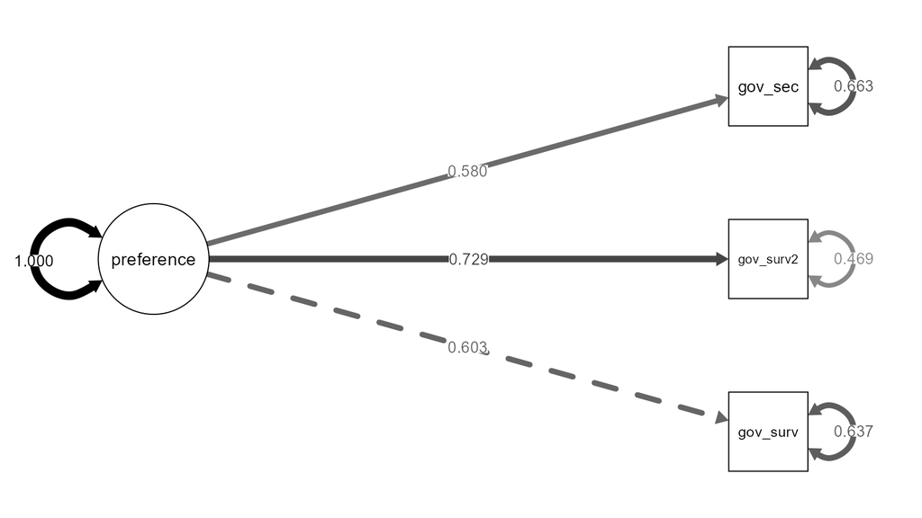

```r
## Figure A2


agg_png(wdir("results/figa2.png"), width = 1600, height = 900)
semPaths(cfa, what = "std", layout = "tree", nodeLabels = c("gov_surv", "gov_surv2","gov_sec", "preference"),sizeLat = 14,sizeMan = 10, edge.color = "black",edge.label.cex = 0.9, nDigits = 3, rotation = 2)
invisible(dev.off())

## Figure A3
agg_png(wdir("results/figa3.png"), width = 1600, height = 900)
semPaths(cfa2, what = "std", layout = "tree", nodeLabels = c("stay", "gather","distance", "behavior"),sizeLat = 14,sizeMan = 10, edge.color = "black",edge.label.cex = 0.9, nDigits = 3, rotation = 2)
invisible(dev.off())

knitr::include_graphics("results/figa2.png")
```

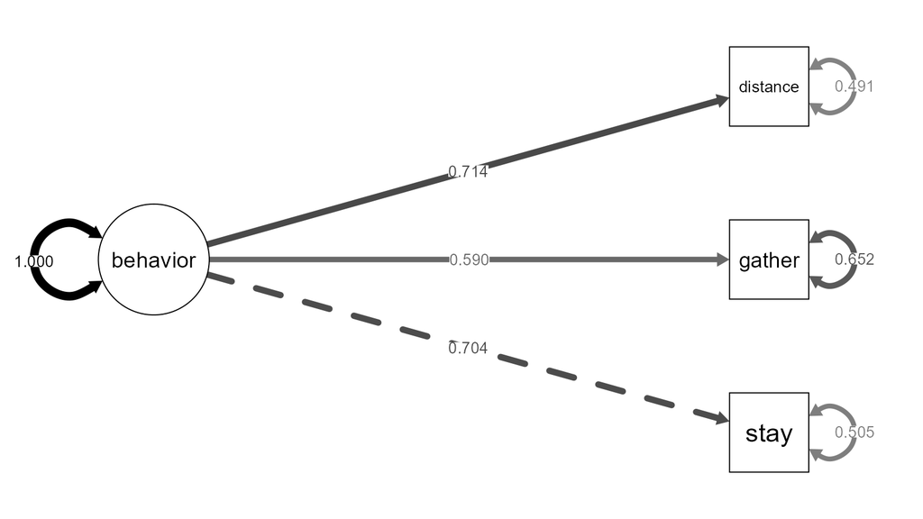

```r
knitr::include_graphics("results/figa3.png")
```

#### Fig 2

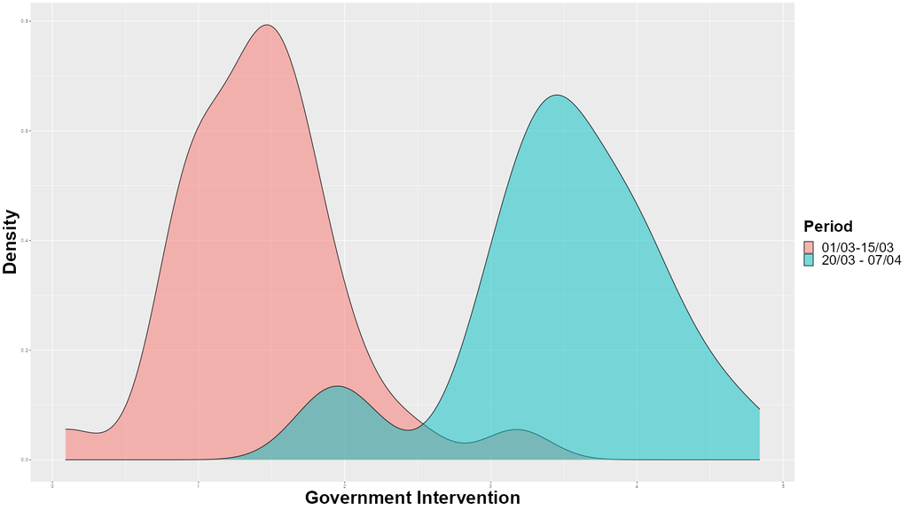

```r
## Figure 3

chi <- c(df$chi1.2, df$chi2.2)
time <- c(rep("first", 32), rep("second", 32))
cntry <- rep(df$cow, 2)
df2 <- as.data.frame(cbind(chi, time, cntry))
df2$time <- as.factor(df2$time)
df2$chi <- as.numeric(df2$chi)
df2$cntry <- as.factor(df2$cntry)

agg_png(wdir("results/fig2.png"),width = 1600,height = 900)
ggplot(data = df2, aes(x = chi, fill = time)) +
  geom_density(alpha = 0.5, trim = FALSE) +
  xlab(label = "Government Intervention") +
  ylab(label = "Density") +
  scale_fill_discrete(name = "Period", labels = c("01/03-15/03","20/03 - 07/04")) +
  theme(axis.title = element_text(size = 32,face = "bold"),legend.title = element_text(size = 28, face = "bold"), legend.text = element_text(size = 24))
invisible(dev.off())

knitr::include_graphics("results/fig2.png")
```

#### Outbreak Stage

Predict residuals from m11 (requires the least degrees of freedom and theoretical assumptions)

#### Table 2

```r
m11 <- lm(chi1 ~ dpm1 + gov_author , data = df)

m12 <- lm(chi1 ~ dpm1 + gov_author + gini_disp, data = df)

m13 <- lm(chi1 ~ dpm1 + gov_author + soc_spend, data = df)

m14 <- lm(chi1 ~ dpm1 + gov_author + gdp, data = df)

m15 <- lm(chi1 ~ dpm1 + gov_author + gini_disp + soc_spend + gdp, data = df)

tab_model(m11, m12, m13, m14, m15, p.style = "stars", p.threshold = c(0.10, 0.05, 0.01), show.ci = F,  dv.labels = c("M11", "M12","M13", "M14","M15"), pred.labels = c("Intercept", "Deaths per Million", "Public Preferences", "Disposable Income Inequality", "Social Spending", "GDP (k$, per capita)"))
```

M11

M12

M13

M14

M15

Predictors

Estimates

Estimates

Estimates

Estimates

Estimates

Intercept

0.24

0.85

0.35

0.24

2.20

Deaths per Million

1.38 **

1.25 *

1.44 **

1.41 **

1.49 **

Public Preferences

-0.12

-0.06

-0.12

-0.11

0.07

Disposable Income Inequality

-0.02

-0.05 *

Social Spending

-0.01

-0.03

GDP (k$, per capita)

-0.00

-0.01

Observations

32

32

32

32

32

R<sup>2</sup> / R<sup>2</sup> adjusted

0.151 / 0.093

0.186 / 0.099

0.154 / 0.064

0.152 / 0.061

0.250 / 0.106

- p<0.1 ** p<0.05 *** p<0.01

```r
df$chi1_p <- predict.lm(m11, newdata = df)
df$gap1 <- round(df$chi1 - df$chi1_p,3)
df$gap1_cat <- as.factor(ifelse(df$gap1 > 0, 1, 0))
df$gap1_tri <- as.factor(
  case_when(
    df$gap1 > 0.05 ~ 1,
    df$gap1 < -0.05 ~ -1,
    TRUE ~ 0
  )
)
```

#### Public Reaction Stage

March 20th - April 7th

Now we take the residuals as the discrepancy. We also control for current level of intervention as this influences behaviors.

#### Table 3

```r
m21 <- lm(behave ~ dpm2 + chi2 , data = df)

m22 <- lm(behave  ~ dpm2 + chi2 + gap1, data = df)

m23 <- lm(behave  ~ dpm2 +  chi2 + gap1  + gini_disp, data = df)

m24 <- lm(behave ~ dpm2 +  chi2 + gap1  + soc_spend, data = df)

m25 <- lm(behave ~ dpm2 + chi2 + gap1 + gdp, data = df)

m26 <- lm(behave ~ dpm2 + chi2 + gap1 + gini_disp + soc_spend + gdp, data = df)



tab_model(m21, m22, m23, m24, m25, m26, p.style = "stars", p.threshold = c(0.10, 0.05, 0.01), show.ci = F,  dv.labels = c("M21", "M22","M23", "M24","M25", "M26"), pred.labels = c("Intercept", "Deaths per Million", "Current Gov. Intervention", "Discrepancy from Outbreak Stage",  "Disposable Income Inequality", "Social Spending", "GDP (k$, per capita)"))
```

M21

M22

M23

M24

M25

M26

Predictors

Estimates

Estimates

Estimates

Estimates

Estimates

Estimates

Intercept

-0.18

-0.16

0.80

-0.72 *

-0.61 **

-0.56

Deaths per Million

0.01 *

0.01

0.01

0.00

0.01

0.00

Current Gov. Intervention

0.51 ***

0.58 ***

0.66 ***

0.65 ***

0.70 ***

0.72 ***

Discrepancy from Outbreak Stage

-0.27

-0.36 *

-0.31

-0.32 *

-0.34 *

Disposable Income Inequality

-0.03

-0.00

Social Spending

0.03

0.01

GDP (k$, per capita)

0.01 **

0.01

Observations

32

32

32

32

32

32

R<sup>2</sup> / R<sup>2</sup> adjusted

0.338 / 0.293

0.385 / 0.319

0.420 / 0.335

0.435 / 0.351

0.470 / 0.391

0.476 / 0.350

- p<0.1 ** p<0.05 *** p<0.01

#### Table 4

```r
m31 <- lm(behave ~ dpm2 + chi2 , data = df)

m32 <- lm(behave  ~ dpm2 + chi2 + gap1_cat, data = df)

m33 <- lm(behave  ~ dpm2 +  chi2 + gap1_cat  + gini_disp, data = df)

m34 <- lm(behave ~ dpm2 +  chi2 + gap1_cat  + soc_spend, data = df)

m35 <- lm(behave ~ dpm2 + chi2 + gap1_cat + gdp, data = df)

m36 <- lm(behave ~ dpm2 + chi2 + gap1_cat + gini_disp + soc_spend + gdp, data = df)



tab_model(m31, m32, m33, m34, m35, m36, p.style = "stars", p.threshold = c(0.10, 0.05, 0.01), show.ci = F,  dv.labels = c("M31", "M32","M33", "M34","M35", "M36"), pred.labels = c("Intercept", "Deaths per Million", "Current Gov. Intervention", "Positive Discrepancy from Outbreak Stage",  "Disposable Income Inequality", "Social Spending", "GDP (k$, per capita)"))
```

M31

M32

M33

M34

M35

M36

Predictors

Estimates

Estimates

Estimates

Estimates

Estimates

Estimates

Intercept

-0.18

0.24

1.30

-0.39

-0.16

-0.37

Deaths per Million

0.01 *

0.01

0.00

-0.00

0.00

0.00

Current Gov. Intervention

0.51 ***

0.58 ***

0.65 ***

0.68 ***

0.68 ***

0.70 ***

Positive Discrepancy from Outbreak Stage

-0.69 **

-0.82 **

-0.85 ***

-0.69 **

-0.81 **

Disposable Income Inequality

-0.03

-0.00

Social Spending

0.04 **

0.03

GDP (k$, per capita)

0.01 *

0.01

Observations

32

32

32

32

32

32

R<sup>2</sup> / R<sup>2</sup> adjusted

0.338 / 0.293

0.438 / 0.378

0.478 / 0.400

0.519 / 0.448

0.504 / 0.431

0.532 / 0.419

- p<0.1 ** p<0.05 *** p<0.01

#### Sensitivity Analysis:

Test as a sensitivity analysis

```r
m4a <- lm(chi3 ~ dpm3 + gov_author, data = df)
df$chi3_p <- predict.lm(m4a, newdata = df)
df$gap2 <- df$chi3 - df$chi3_p

m41 <- lm(behave ~ dpm3 + chi2, data = df)

m42 <- lm(behave ~ dpm3 + gap2 + chi2, data = df)

m43 <- lm(behave ~ dpm3 + gap2 + chi2 + gini_disp , data = df)

m44 <- lm(behave ~ dpm3 + gap2 + chi2 + soc_spend , data = df)

m45 <- lm(behave ~ dpm3 + gap2 + chi2 + gdp, data = df)

m46 <- lm(behave ~ dpm3 + gap2 + chi2 + gini_disp + soc_spend + gdp, data = df)



tab_model(m41, m42, m43, m44, m45, m46, p.style = "stars", p.threshold = c(0.10, 0.05, 0.01), show.ci = F,  dv.labels = c("M41", "M42","M43", "M44","M45", "M46"), pred.labels = c("Intercept", "Deaths per Million", "Current Gov. Intervention", "Discrepancy from Outbreak Phase", "Disposable Income Inequality", "Social Spending", "GDP (k$, per capita)"))
```

M41

M42

M43

M44

M45

M46

Predictors

Estimates

Estimates

Estimates

Estimates

Estimates

Estimates

Intercept

-0.14

-0.15

0.81

-0.76 *

-0.62 **

-0.83

Deaths per Million

0.32

0.32

0.24

0.13

0.19

0.13

Current Gov. Intervention

0.51 ***

0.60 ***

0.68 ***

0.66 ***

0.73 ***

0.73 ***

Discrepancy from Outbreak Phase

-0.24

-0.32

-0.24

-0.28

-0.27

Disposable Income Inequality

-0.03

0.00

Social Spending

0.04 *

0.02

GDP (k$, per capita)

0.02 **

0.01

Observations

32

32

32

32

32

32

R<sup>2</sup> / R<sup>2</sup> adjusted

0.293 / 0.244

0.333 / 0.261

0.369 / 0.276

0.398 / 0.309

0.427 / 0.342

0.437 / 0.302

- p<0.1 ** p<0.05 *** p<0.01

#### Alternative Figure - Residuals and Behavior Compared

Our argument rests on counterfactual logic. This means that net of the current government intervention (which has a large impact), how would have people behaved if the intervention in the Outbreak Phase was different.

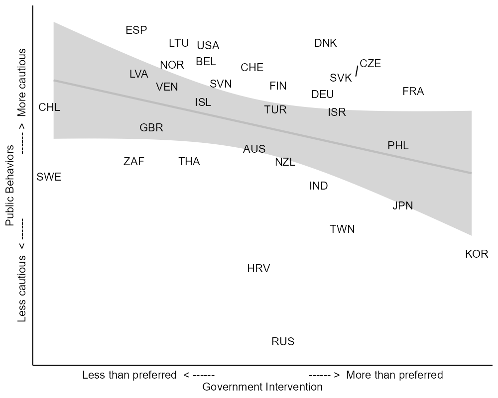

```r
# Create partial correlation (predicted behave partialled out from chi2)
partial <- lm(behave ~ chi2, data = df)
df$behave_p <- predict(partial, newdata = df)
df$behave_partial <- df$behave - df$behave_p

# add country ISO 3c
df$iso <- countrycode(df$cow, "cown", "iso3c")

# fix Chile as outlier for better visualization (to the level of SWE)
df$gap1i <- ifelse(df$iso == "CHL", -1.6, df$gap1)

agg_png(filename = "results/Fig_new.png", res = 144, height = 800, width = 1000)
ggplot(df, aes(gap1i, behave_partial, label = iso)) +
  geom_smooth(method = "lm", color = "grey") +
  geom_text_repel(aes(label = iso)) +
  labs(x = "Less than preferred  < ------                               ------ >  More than preferred\nGovernment Intervention", y = "Public Behaviors\nLess cautious  < ------                     ------ >  More cautious") +
  theme_classic() +
  theme(axis.text = element_blank(),
        axis.ticks = element_blank())
invisible(dev.off())

knitr::include_graphics("results/Fig_new.png")
```

#### Sample Representativeness

```r
betrack <- read_dta(wdir("data/GlobalBehaviorsPerceptions_Data_May21_2020.dta"))


betrack <- betrack %>%
  mutate(
    cow = countrycode(iso2c, origin = "iso2c", destination = "cown"),
    stay = beh_stayhome/20,
    gather = beh_socgathering/20,
    distance = beh_distance/20,
    tsymp = beh_tellsymp/20,
    hwash = beh_handwash/20
  ) %>%
  filter(cow %in% df$cow) %>%
  mutate(
    age_cat = age_yr_bin,
    female = ifelse(gender %in% c(1,2), gender - 1, NA_real_),
    edu_cat = educ_bin,
    edu_yrs = educ,
    inc_cat = inc_bin,
    behave = round((stay + 0.776*gather + 1.083*distance)/3,2)
  )
```

```r
betrack$cntry <- countrycode(betrack$cow, "cown","country.name")
## Figure A.3
agg_png(wdir("figures/figa3.png"),width = 1600,height = 900)
ggplot(data = betrack, aes(x = age, fill = as.factor(cntry))) +
  geom_density(alpha = 0.5, trim = FALSE) +
  xlab(label = "Age") +
  ylab(label = "Density") +
  scale_fill_discrete(name = "Country") +
  theme(axis.title = element_text(size = 24,face = "bold"),legend.title = element_text(size = 24, face = "bold"), legend.text = element_text(size = 16))
invisible(dev.off())
## Figure A.4
betrack_a4 <- betrack[complete.cases(betrack$edu_cat),]
agg_png(wdir("figures/figa4.png"),width = 1600,height = 900)
ggplot(data = betrack_a4, aes(x = as.factor(edu_cat), fill = as.factor(cntry))) +
  geom_bar() +
  xlab(label = "Education categories") +
  ylab(label = "Count") +
  coord_flip() +
  scale_fill_discrete(name = "Country") +
  theme(axis.title = element_text(size = 24,face = "bold"),legend.title = element_text(size = 24, face = "bold"), legend.text = element_text(size = 16))
invisible(dev.off())

## Figure A.5
betrack_a5 <- betrack[complete.cases(betrack$inc_cat),]
agg_png(wdir("figures/figa5.png"),width = 1600,height = 900)
ggplot(data = betrack_a5, aes(x = as.factor(inc_cat), fill = as.factor(cntry))) +
  geom_bar() +
  xlab(label = "Income categories") +
  ylab(label = "Count") +
  coord_flip() +
  scale_fill_discrete(name = "Country") +
  theme(axis.title = element_text(size = 24,face = "bold"),legend.title = element_text(size = 24, face = "bold"), legend.text = element_text(size = 16))
invisible(dev.off())

## Figure A6
betrack_a6 <- betrack[complete.cases(betrack$female),]

agg_png(wdir("figures/figa6.png"),width = 1600,height = 900)
ggplot(data = betrack_a6, aes(x = as.factor(female), fill = as.factor(cntry))) +
  geom_bar() +
  xlab(label = "Female") +
  ylab(label = "Count") +
  coord_flip() +
  scale_fill_discrete(name = "Country") +
  theme(axis.title = element_text(size = 24,face = "bold"),legend.title = element_text(size = 24, face = "bold"), legend.text = element_text(size = 16))
invisible(dev.off())
```